Loading Lib

```r
library(ggplot2)
library(dplyr)
```

Loading msleep data from ggplot package

```r
data(msleep)
head(msleep, 5)
```

```
## # A tibble: 5 × 11
##   name    genus vore  order conservation sleep_total sleep_rem sleep_cycle awake
##   <chr>   <chr> <chr> <chr> <chr>              <dbl>     <dbl>       <dbl> <dbl>
## 1 Cheetah Acin… carni Carn… lc                  12.1      NA        NA      11.9
## 2 Owl mo… Aotus omni  Prim… <NA>                17         1.8      NA       7
## 3 Mounta… Aplo… herbi Rode… nt                  14.4       2.4      NA       9.6
## 4 Greate… Blar… omni  Sori… lc                  14.9       2.3       0.133   9.1
## 5 Cow     Bos   herbi Arti… domesticated         4         0.7       0.667  20
## # ℹ 2 more variables: brainwt <dbl>, bodywt <dbl>
```

# MEASURE CENTRAL TENDENCY ->

## mean

```r
mean(msleep$sleep_total)
```

```
## [1] 10.43373
```

## median

```r
median(msleep$sleep_total)
```

```
## [1] 10.1
```

## mode

```r
msleep %>%
  count(sleep_total, sort = TRUE) %>% head()
```

```
## # A tibble: 6 × 2
##   sleep_total     n
##         <dbl> <int>
## 1        12.5     4
## 2        10.1     3
## 3         5.3     2
## 4         6.3     2
## 5         8.4     2
## 6         8.7     2
```

Now that we have lots of ways to measure center, how do we know which one to use? Let’s look at an example. Here, we have all of the insectivores in the dataset.

- Step 1 : Filter out vore == “insecti” & store in a object called msleep_insecti
- Step 2 : Then check mean and median of sleep_total column from msleep_insecti
- Step 2 : Remove out the row from msleep_insecti which have the least sleep_total value and then again check the mean and median of msleep_insecti

*You will notice that just by removing few rows from msleep based on least sleep_total value, the mean has shifted drastically whereas, the median have not.*

```r
msleep_insecti <- msleep %>%
  filter(vore == "insecti")

msleep_insecti
```

```
## # A tibble: 5 × 11
##   name    genus vore  order conservation sleep_total sleep_rem sleep_cycle awake
##   <chr>   <chr> <chr> <chr> <chr>              <dbl>     <dbl>       <dbl> <dbl>
## 1 Big br… Epte… inse… Chir… lc                  19.7       3.9       0.117   4.3
## 2 Little… Myot… inse… Chir… <NA>                19.9       2         0.2     4.1
## 3 Giant … Prio… inse… Cing… en                  18.1       6.1      NA       5.9
## 4 Easter… Scal… inse… Sori… lc                   8.4       2.1       0.167  15.6
## 5 Short-… Tach… inse… Mono… <NA>                 8.6      NA        NA      15.4
## # ℹ 2 more variables: brainwt <dbl>, bodywt <dbl>
```

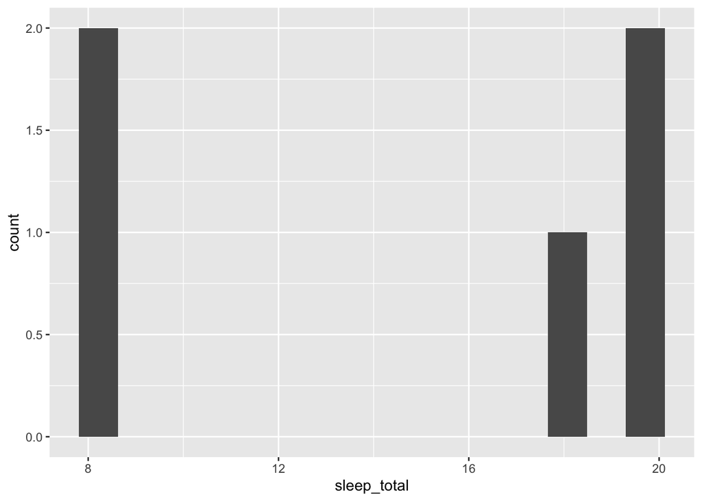

```r
msleep_insecti %>%
  ggplot(aes(sleep_total)) +
  geom_histogram(bins = 15)
```

```r
msleep_insecti %>%
  summarise(mean_sleep = mean(sleep_total), median_sleep = median(sleep_total))
```

```
## # A tibble: 1 × 2
##   mean_sleep median_sleep
##        <dbl>        <dbl>
## 1       14.9         18.1
```

```r
msleep_insecti %>%
  filter(sleep_total >= 9) %>%
  summarise(mean_sleep = mean(sleep_total), median_sleep = median(sleep_total))
```

```
## # A tibble: 1 × 2
##   mean_sleep median_sleep
##        <dbl>        <dbl>
## 1       19.2         19.7
```

- Mean shifted from 14.94 to 19.2333
- Median shifted from 18.1 to 19.7 Because mean is more sensitive to extreme values than median so it works better for symmetrical data like this. However, if the data is skewed, meaning it’s not symmetrical, like this, median is usually better to use.

When data is skewed, the mean and median are different. The mean is pulled in the direction of the skew, so it’s lower than the median on the left-skewed data, and higher than the median on the right-skewed data. Because the mean is pulled around by the extreme values, it’s better to use the median since it’s less affected by outliers.

# MEASURE OF SPREAD ->

Spread is just what it sounds like - it describes how spread apart or close together the data points are. Just like measures of center, there are a few different measures of spread.

## 1. Variance -

```
Variance, measures the average distance from each data point to the
data's mean.
```

calculating variance - step 1. We start by calculating the distance between each point and the mean, so we get one number for every data point.

```r
dists <- msleep$sleep_total - mean(msleep$sleep_total)
dists
```

```
##  [1]  1.66626506  6.56626506  3.96626506  4.46626506 -6.43373494  3.96626506
##  [7] -1.73373494 -3.43373494 -0.33373494 -7.43373494 -5.13373494 -1.03373494
## [13] -0.43373494  2.06626506 -0.13373494 -2.13373494 -1.33373494  6.96626506
## [19] -5.13373494  7.56626506 -6.53373494  9.26626506 -7.53373494 -7.33373494
## [25] -0.33373494  0.46626506  4.46626506  2.06626506 -0.63373494 -8.53373494
## [31] -7.73373494 -4.23373494 -4.13373494 -2.43373494 -0.93373494 -7.13373494
## [37]  8.96626506 -0.33373494  3.76626506  3.86626506  2.36626506  2.06626506
## [43]  9.46626506  4.16626506  0.56626506 -2.73373494  4.06626506 -2.03373494
## [49] -6.63373494 -0.73373494  5.36626506 -0.03373494  3.06626506 -1.03373494
## [55] -0.13373494  0.56626506  1.06626506  3.26626506 -6.93373494 -4.83373494
## [61]  0.66626506  7.66626506 -5.03373494  2.56626506 -1.73373494 -0.83373494
## [67] -2.03373494  0.86626506  0.16626506  6.16626506  3.36626506  5.46626506
## [73]  2.36626506 -1.33373494 -1.83373494  5.36626506 -6.03373494  5.16626506
## [79] -1.53373494 -5.23373494 -4.13373494  2.06626506 -0.63373494
```

step 2. We then square each distance and then add them all together.

```r
squared_dist <- (dists)^2
```

```r
sum_squared_dist <- sum(squared_dist)
sum_squared_dist
```

```
## [1] 1624.066
```

```r
sum_squared_dist/nrow(msleep) - 1
```

```
## [1] 18.56705
```

The higher the variance, the more spread out the data is. It’s important to note that the units of variance are squared, so in this case, it’s 19.8 hours squared. We can calculate the variance in one step using the var function.

```r
var(msleep$sleep_total)
```

```
## [1] 19.80568
```

## 2. Standard deviation -

```
The standard deviation is another measure of spread, calculated by
taking the square root of the variance
```

```r
sqrt(var(msleep$sleep_total))
```

```
## [1] 4.450357
```

```r
sd(msleep$sleep_total)
```

```
## [1] 4.450357
```

The nice thing about standard deviation is that the units are usually easier to understand since they’re not squared.

## 3. Mean absolute deviation -

```
Mean absolute deviation takes the absolute value of the distances to
the mean, and then takes the mean of those differences
```

```r
dist <- msleep$sleep_total - mean(msleep$sleep_total) # many data points (this is dist to the mean)
mean(abs(dist))
```

```
## [1] 3.566701
```

While this is similar to standard deviation, it’s not exactly the same. Standard deviation squares distances, so longer distances are penalized more than shorter ones, while mean absolute deviation penalizes each distance equally. One isn’t better than the other, but SD is more common than MAD.

## Quartiles -

Quartiles split up the data into four equal parts. Here, we call the quantile function to get the quartiles of the data.This means that the second quartile splits the data in two, with 50% of the data below it and 50% of the data above it, so it’s exactly the same as the median.

```r
quantile(msleep$sleep_total)
```

```
##    0%   25%   50%   75%  100%
##  1.90  7.85 10.10 13.75 19.90
```

This means that 25% of the data is between 1.9 and 7.85, another 25% is between 7.85 and 10.10, and so on.

```r
min(msleep$sleep_total)
```

```
## [1] 1.9
```

```r
max(msleep$sleep_total)
```

```
## [1] 19.9
```

## Boxplot using quartiles -

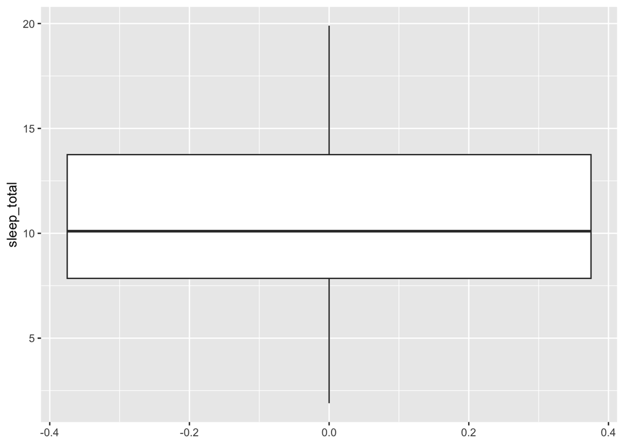

```r
ggplot(msleep,aes(y=sleep_total)) +
  geom_boxplot()
```

The boxes in box plots represent quartiles. The bottom of the box is the first quartile, and the top of the box is the third quartile. The middle line is the second quartile, or the median.

## Quantiles -

Quantiles, also called percentiles, are a generalized version of quartile, so they can split data into 5 pieces or ten pieces, for example. By default, the quantile function returns the quartiles of the data, but we can adjust this using the probs argument, which takes in a vector of proportions. Here, we split the data in five equal pieces. We can also use the seq function as a shortcut, which takes in the lowest number, the highest number, and the number we want to jump by. We can compute the same quantiles using seq from zero to one, jumping by 0-.2.

ex : Calculate the six quantiles that split up the data into 5 pieces (quintiles) of the sleep_total column of msleep dataset.

```r
quantile(msleep$sleep_total, probs = c(0,0.2,0.4,0.6,0.8,1))
```

```
##    0%   20%   40%   60%   80%  100%
##  1.90  6.24  9.48 11.14 14.40 19.90
```

```r
quantile(msleep$sleep_total, probs = seq(0,1,0.2))
```

```
##    0%   20%   40%   60%   80%  100%
##  1.90  6.24  9.48 11.14 14.40 19.90
```

Calculate the eleven quantiles of sleep_total that split up the data into ten pieces (deciles).

```r
quantile(msleep$sleep_total, probs = seq(0,1,0.1))
```

```
##    0%   10%   20%   30%   40%   50%   60%   70%   80%   90%  100%
##  1.90  3.92  6.24  8.52  9.48 10.10 11.14 12.80 14.40 15.88 19.90
```

## Interquartile range (IQR) -

The interquartile range, or IQR, is another measure of spread. It’s the distance between the 25th and 75th percentile, which is also the height of the box in a boxplot (lower line in a box plot is Q1, middle is Q2 and upper is Q3)

```r
quantile(msleep$sleep_total, 0.75) - quantile(msleep$sleep_total, 0.25) #Q3-Q1
```

```
## 75%
## 5.9
```

Outliers - Outliers are data points that are substantially different from the others. But how do we know what a substantial difference is? A rule that’s often used is that any data < Q1 - 1.5 * IQR # LOWER_THRESHOLD or data > Q3 + 1.5 * IQR # UPPER_THRESHOLD

## Finding outliers -

step 1. we’ll start by calculating the IQR of the mammals’ body weights. step 2.We can then calculate the lower and upper thresholds following the formulas from the previous slide. step 3. We can now filter the data frame to find mammals whose body weight is above or below the thresholds.

```r
IQR <- quantile(msleep$bodywt, 0.75) - quantile(msleep$bodywt, 0.25)
IQR
```

```
##    75%
## 41.576
```

```r
lower_threshold <- quantile(msleep$bodywt, 0.25) - 1.5 *IQR
lower_threshold
```

```
##    25%
## -62.19
```

```r
upper_threshold <- quantile(msleep$bodywt, 0.75) + 1.5 *IQR
upper_threshold
```

```
##     75%
## 104.114
```

```r
msleep %>%
  filter(bodywt < lower_threshold | bodywt > upper_threshold ) %>%
  select(name, vore, sleep_total, bodywt)
```

```
## # A tibble: 11 × 4
##    name                 vore  sleep_total bodywt
##    <chr>                <chr>       <dbl>  <dbl>
##  1 Cow                  herbi         4     600
##  2 Asian elephant       herbi         3.9  2547
##  3 Horse                herbi         2.9   521
##  4 Donkey               herbi         3.1   187
##  5 Giraffe              herbi         1.9   900.
##  6 Pilot whale          carni         2.7   800
##  7 African elephant     herbi         3.3  6654
##  8 Tiger                carni        15.8   163.
##  9 Lion                 carni        13.5   161.
## 10 Brazilian tapir      herbi         4.4   208.
## 11 Bottle-nosed dolphin carni         5.2   173.
```

We can see that there are eleven body weight outliers in this dataset, including the cow and the Asian elephant.

# EXERCISE

## question 1

Calculate the variance and standard deviation of co2_emission for each food_category by grouping by and summarizing variance as var_co2 and standard deviation as sd_co2. Create a histogram of co2_emission for each food_category using facet_wrap().

```r
library(readr)
food_consumption <- read.csv("food_consumption.csv")
head(food_consumption,10)
```

```
##     X   country food_category consumption co2_emission
## 1   1 Argentina          pork       10.51        37.20
## 2   2 Argentina       poultry       38.66        41.53
## 3   3 Argentina          beef       55.48      1712.00
## 4   4 Argentina     lamb_goat        1.56        54.63
## 5   5 Argentina          fish        4.36         6.96
## 6   6 Argentina          eggs       11.39        10.46
## 7   7 Argentina         dairy      195.08       277.87
## 8   8 Argentina         wheat      103.11        19.66
## 9   9 Argentina          rice        8.77        11.22
## 10 10 Argentina      soybeans        0.00         0.00
```

```r
food_consumption %>%
  group_by(food_category) %>%
  summarize(var = var(co2_emission), sd = sd(co2_emission))
```

```
## # A tibble: 11 × 3
##    food_category       var      sd
##    <chr>             <dbl>   <dbl>
##  1 beef          88748.    298.
##  2 dairy         17672.    133.
##  3 eggs             21.4     4.62
##  4 fish            922.     30.4
##  5 lamb_goat     16476.    128.
##  6 nuts             35.6     5.97
##  7 pork           3095.     55.6
##  8 poultry         245.     15.7
##  9 rice           2281.     47.8
## 10 soybeans          0.880   0.938
## 11 wheat            71.0     8.43
```

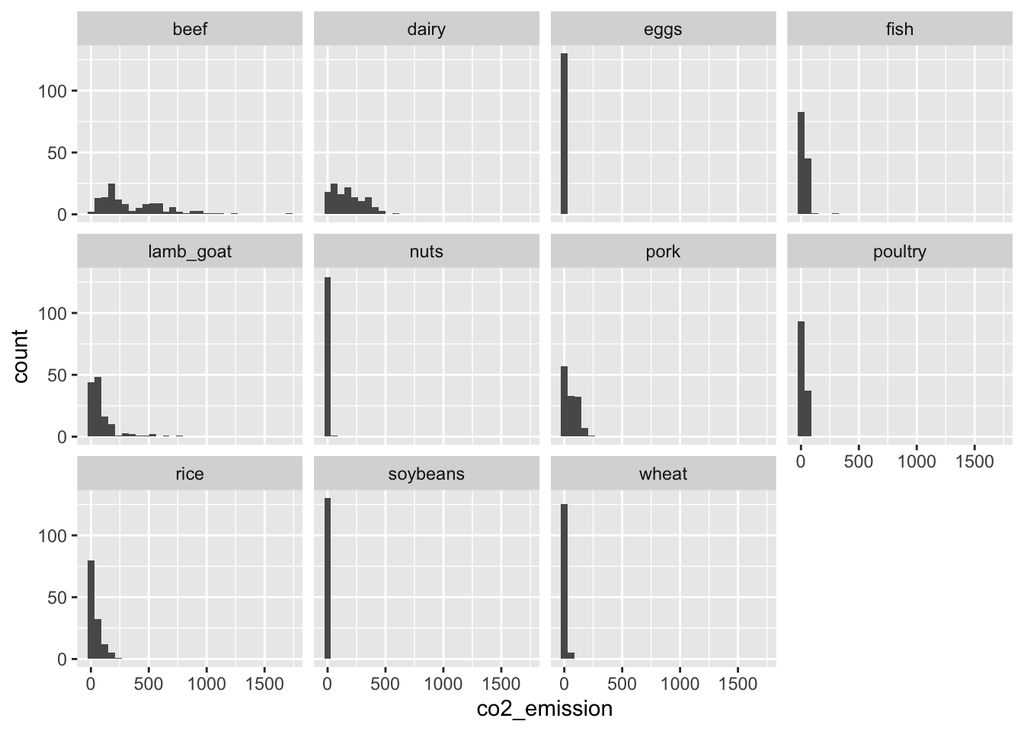

```r
ggplot(data = food_consumption, aes(x = co2_emission)) +
  geom_histogram() +
  facet_wrap(~ food_category)
```

Superb spread measurement! Beef has the biggest amount of variation in its CO2 emissions, while eggs, nuts, and soybeans have relatively small amounts of variation.

## question 2

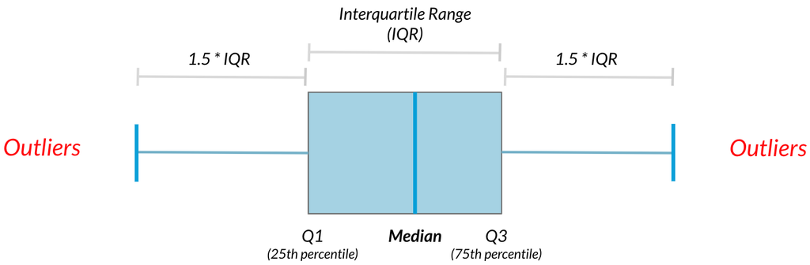

- Calculate the total `co2_emission` per country by grouping by country and taking the sum of `co2_emission`. Call the sum `total_emission` and store the resulting data frame as `emissions_by_country`.
- Compute the first and third quartiles of `total_emission` and store these as `q1` and `q3`.
- Calculate the interquartile range of `total_emission` and store it as `iqr`.
- Calculate the lower and upper cutoffs for outliers of `total_emission`, and store these as `lower` and `upper`
- Use `filter()` to get countries with a `total_emission` greater than the `upper` cutoff **or** a `total_emission` less than the `lower` cutoff.

```r
head(food_consumption)
```

```
##   X   country food_category consumption co2_emission
## 1 1 Argentina          pork       10.51        37.20
## 2 2 Argentina       poultry       38.66        41.53
## 3 3 Argentina          beef       55.48      1712.00
## 4 4 Argentina     lamb_goat        1.56        54.63
## 5 5 Argentina          fish        4.36         6.96
## 6 6 Argentina          eggs       11.39        10.46
```

```r
emissions_by_country <- food_consumption %>%
  group_by(country) %>%
  summarize(total_emission = sum(co2_emission))
emissions_by_country
```

```
## # A tibble: 130 × 2
##    country    total_emission
##    <chr>               <dbl>
##  1 Albania             1778.
##  2 Algeria              708.
##  3 Angola               413.
##  4 Argentina           2172.
##  5 Armenia             1110.
##  6 Australia           1939.
##  7 Austria             1211.
##  8 Bahamas             1193.
##  9 Bangladesh           374.
## 10 Barbados             889.
## # ℹ 120 more rows
```

```r
q1 <- quantile(emissions_by_country$total_emission, 0.25)
q1
```

```
##    25%
## 446.66
```

```r
q3 <- quantile(emissions_by_country$total_emission, 0.75)
q3
```

```
##      75%
## 1111.152
```

```r
iqr <- q3 - q1
iqr
```

```
##      75%
## 664.4925
```

```r
lower <- q1 - 1.5 * iqr #Q1 - 1.5 * IQR
lower
```

```
##       25%
## -550.0788
```

```r
upper <- q3 + 1.5 * iqr #Q3 - 1.5 * IQR
upper
```

```
##      75%
## 2107.891
```

```r
emissions_by_country %>%
  filter(total_emission < lower | total_emission > upper)
```

```
## # A tibble: 1 × 2
##   country   total_emission
##   <chr>              <dbl>
## 1 Argentina          2172.
```

Outstanding outlier detection! It looks like Argentina has a substantially higher amount of CO2 emissions per person than other countries in the world. Above row is an outlier.